# Data Science: With The Beatles!

### Message 5: Wow, yes! there's been a lot of songs on the charts with runs longer than the Beatles longest running song, Twist and Shout at 26 weeks. The longest being Glass Animals with Heat Waves at a wopping 91 weeks! The bar plot shows the magnitude of difference at scale. I was not expecting that... :( Not to take anything away from Glass Animals' achievement, but this *was* during the Covid-19 lockdown from 2020-2021 when no or very little new music was being recorded or published...Not a whole lot of competition on the charts.) <-- **"Industry Knowledge / Insight"** - Gotten from experience in or familiarity with an industry.

### Motivation 6: How many other bands have hit #1 like the Beatles? How many other songs have hit #1?

### Method 6: First, I'm curious about how many number one songs are in the file. Then I want to use **Data Visualization** to see what the distribution of #1 hits to the rest of the chart looks like, because my hypothesis is that I'm thinking there'll be less #1 songs than other chart rankings, because it seems #1 would be the hardest chart position to reach.

### Mechanics 6: Review counts of all columns if data records are of #1 hits.

#### Python variable: df2 - another raw data source recordset, meant to be used for all artists as df will be transformed into just Beatles records later on

#### Python method: pandas.count()

```python
df2[df2['peak_pos']==1].count()
```

```
chart_week      17762
current_week    17762
title           17762
performer       17762
last_week       17671
peak_pos        17762
wks_on_chart    17762
dtype: int64
```

### Message 6: Close, but that's just a count of RECORDS that the non-NaN values in the columns where "1" is the value in the peak_pos column, but there could be many records for the same song with a peak_pos of 1. What I do find interesting is that there appear to be some songs that debuted at #1 b/c there are some songs that have a NaN (discovered above) for the last_week column. Here's the proof that exists below (see Taylor Swift's "All Too Well", Coldplay with BTS' "My Universe", and Ricky Nelson's "Poor Little Fool").

```python
%%html
<iframe width="560" height="315" src="https://www.youtube.com/embed/3YqPKLZF_WU?si=KY4Rj5W1MYjhstSv&autoplay=1;&amp;controls=1" title="YouTube video player" frameborder="0" allow="accelerometer; clipboard-write; encrypted-media; gyroscope; picture-in-picture; web-share" allowfullscreen></iframe>
<h3>Press the YouTube logo at the bottom of the video screen above to pop-out to a different tab and listen to in the background while you keep reading!</h3>
```

[video not shown]

Press the YouTube logo at the bottom of the video screen above to pop-out to a different tab and listen to in the background while you keep reading!

```python
print(df2[(df2['last_week'].isnull())&(
    df2['peak_pos']==1)].sort_values(['chart_week'], ascending=False))
```

```
        chart_week  current_week                            title  \
341235  2021-11-27            36  All I Want For Christmas Is You
341200  2021-11-27             1  All Too Well (Taylor's Version)
341439  2021-11-13            40                     Ghostbusters
341436  2021-11-13            37                     Monster Mash
338900  2021-10-09             1                      My Universe
...            ...           ...                              ...
104387  1976-07-17            88                Ode To Billie Joe
101897  1976-01-24            98                            Venus
63290   1968-08-31            91                    Light My Fire
27854   1961-11-13            55                        The Twist
10700   1958-08-04             1                 Poor Little Fool

                                          performer  last_week  peak_pos  \
341235                                 Mariah Carey        NaN         1
```

[output cut: 25 more lines]

### Motivation 7: At a high-level, compare hit-making success (or failure) of all Billboard Hot 100 artists to hit-making success of the Beatles.

### Method 7: **Data Binning:** First, I'll isolate the Beatles raw data and visually compare shape of highest chart positions and number of songs at those positions for entire body of work versus all artists' bodies of works at highest chart positions and number of songs at those positions for entire history of Billboard Hot 100 to gain insight. (I predict the "All Artists" bin's histogram has a long tail to the left so neg skewness since it would seem to be harder to get a #1.) Since this is a high-level analysis, these will be histograms since it is numeric data, and I can do one-hot swapping of the categoricals maybe once I get to regression (i.e. redefining of text values into boolean values if exist in record or not) to review and maybe visualize.

### Mechanics 7: Use dataframes to manipulate data and visualize into histogram distributions.

#### Python function: pandas.groupby(); pyplot.xlabel("[text]") - label for x-axis for graph; pyplot.ylabel("[text]") - label for y-axis on graph; pyplot.hist([dataframe column / variable storing column]) - creates graph in memory but doesn't make visible; pyplot.title('[text]') - creates label for the graph; pyplot.show() - reveals the graph previously created by pyplot graph function (e.g. hist() )

#### Python method: pandas.transform();

#### Python attribute returned via method call: pandas.head() - shows sample table layout; all columns with first 5 rows

#### Python variables: df - uncollapsed raw data source dataframe with song_woc_max and song_peak_min columns added here; df2 - same as df but w/o song_woc_max & song_peak_min columns added; max1 - collapsed by groupby() w/o transform version of df2 (aka max2) but with only Beatles records; max3 - collapsed by groupby() w/o transform version of df2 with all artists' records (aka max2) but sorted in descending order by max weeks on chart

#### Python parameter: as_index=False - prevents the columns specified in the group by from becoming the index of the resulting recordset, leaving them just as regular columns and instead creates a numerical, sequential index column which allows more straightforward use of Python record attributes like iloc[index_num]

```python
# adding two new columns to the df (all performers)
# max weeks on chart & highest chart position
# transform method doesn't bin/bucket/collapse into one record per act/song
# it keeps original shape of dataframe (orig # of rows & cols. + new cols.)
df['song_woc_max'] = df.groupby(
    ['performer', 'title'], as_index=False)['wks_on_chart'].transform('max')
df['song_peak_min'] = df.groupby(
    ['performer', 'title'], as_index=False)['peak_pos'].transform('min')
```

```python
max1['song_peak_min'] = df2.groupby(
    ['performer', 'title'], as_index=False)['peak_pos'].transform('min')
# max2['song_peak_min'] = df2.groupby(['performer', 'title'], as_index=False)['peak_pos'].transform('min')
max3['song_peak_min'] = df2.groupby(
    ['performer', 'title'], as_index=False)['peak_pos'].transform('min')
```

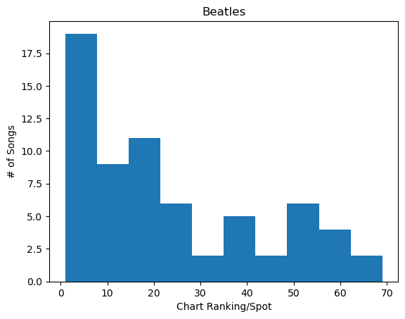

```python
plt.xlabel("Chart Ranking/Spot")
plt.ylabel("# of Songs")
plt.hist(max1['song_peak_min']);
plt.title('Beatles');
plt.show()
```

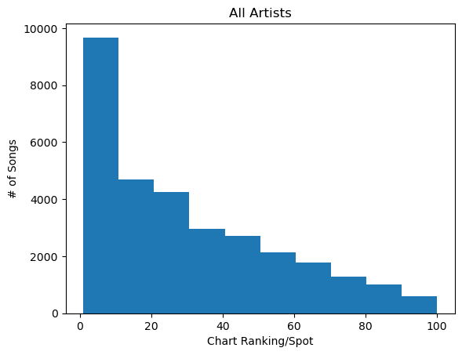

```python
plt.xlabel("Chart Ranking/Spot")
plt.ylabel("# of Songs")
plt.hist(x='song_peak_min', data=max3); # diff way of doing hist() syntax
plt.title("All Artists");
```

### Motivation 8: What is the average max peak_pos and average max wks_on_chart for entire file (all title/band combos)?

### Method 8: Take the means of the above columns. Maybe Visualize?

### Mechanics 8: Use dataframe function(s) describe() and set mean to a variable

#### Python functions: groupby()

#### Python variables: maxwks_minpeak_all - comes up with 2 new columns relating max weeks on chart & peak position for each performer/title combo over all weeks combo appeared on the chart

#### Python attribute returned via method call: pandas.head() - shows sample table layout; all columns with first 5 rows

#### Python parameter: as_index=False - prevents the columns specified in the group by from becoming the index of the resulting recordset, leaving them just as regular columns and instead creates a numerical, sequential index column which allows more straightforward use of Python record attributes like iloc[index_num]

```python
maxwks_minpeak_all = df2.groupby(
    ['performer', 'title'], as_index=False
    ).agg({'wks_on_chart': 'max', 'peak_pos': 'min'})
maxwks_minpeak_all.head()
```

|  | performer | title | wks_on_chart | peak_pos |
| --- | --- | --- | --- | --- |
| 0 | "Groove" Holmes | Misty | 11 | 44 |
| 1 | "Groove" Holmes | What Now My Love | 3 | 96 |
| 2 | "Little" Jimmy Dickens | May The Bird Of Paradise Fly Up Your Nose | 10 | 15 |
| 3 | "Pookie" Hudson | I Know I Know | 1 | 96 |
| 4 | "Weird Al" Yankovic | Amish Paradise | 16 | 53 |

```python
%%html
<iframe width="560" height="315" src="https://www.youtube.com/embed/lOfZLb33uCg?si=KY4Rj5W1MYjhstSv&autoplay=1;&amp;controls=1" title="YouTube video player" frameborder="0" allow="accelerometer; clipboard-write; encrypted-media; gyroscope; picture-in-picture; web-share" allowfullscreen></iframe>
<h3>Press the YouTube logo at the bottom of the video screen above to pop-out to a different tab and listen to in the background while you keep reading!</h3>
```

[video not shown]

Press the YouTube logo at the bottom of the video screen above to pop-out to a different tab and listen to in the background while you keep reading!

```python
maxwks_minpeak_all.describe()
```

|  | wks_on_chart | peak_pos |
| --- | --- | --- |
| count | 31052.000000 | 31052.000000 |
| mean | 11.011883 | 46.795826 |
| std | 8.514665 | 30.461866 |
| min | 1.000000 | 1.000000 |
| 25% | 4.000000 | 19.000000 |
| 50% | 9.000000 | 46.000000 |
| 75% | 16.000000 | 73.000000 |
| max | 91.000000 | 100.000000 |

```python
# so the average peak position of a band/title combo on the charts is
min_peak_pos_mean = maxwks_minpeak_all.agg(x=('peak_pos','mean'))
min_peak_pos_mean
```

|  | peak_pos |
| --- | --- |
| x | 46.795826 |

### Message 8: Avg min peak position for all artist-song combos is 47 (includes Beatles). Almost 50 as CLT (Central Limit Theorem) predicts.

### Motivation 9: What is Beatles avg. minimum peak pos.?

### Method 9: take the mean of all the Beatles songs' minimum peak positions

### Mechanics 9: Aggregate the max1 dataframe to take the mean of all of the minimum peak positions of each Beatles song

#### Python functions: groupby()

#### Python parameter: as_index=False - prevents the columns specified in the group by from becoming the index of the resulting recordset, leaving them just as regular columns and instead creates a numerical, sequential index column which allows more straightforward use of Python record attributes like iloc[index_num]

```python
print(max1) # Beatles minimum peak position data
```

```
         performer                             title  wks_on_chart  \
25563  The Beatles                   Twist And Shout            26
25525  The Beatles                          Hey Jude            19
25514  The Beatles           Come Together/Something            16
25522  The Beatles       Got To Get You Into My Life            16
25551  The Beatles                     She Loves You            15
...            ...                               ...           ...
25565  The Beatles                      What Goes On             2
25539  The Beatles                      Now And Then             2
25561  The Beatles                   There's A Place             1
25559  The Beatles                   The Inner Light             1
25533  The Beatles  I'm Happy Just To Dance With You             1

       song_peak_min
25563             59
25525              2
25514              1
25522             23
25551             19
...              ...
25565             24
25539              6
25561             58
25559             54
25533              3

[66 rows x 4 columns]
```

```python
%%html
<iframe width="560" height="315" src="https://www.youtube.com/embed/958mJ3rV_LQ?si=KY4Rj5W1MYjhstSv&autoplay=1;&amp;controls=1" title="YouTube video player" frameborder="0" allow="accelerometer; clipboard-write; encrypted-media; gyroscope; picture-in-picture; web-share" allowfullscreen></iframe>
<h3>Press the YouTube logo at the bottom of the video screen above to pop-out to a different tab and listen to in the background while you keep reading!</h3>
```

[video not shown]

Press the YouTube logo at the bottom of the video screen above to pop-out to a different tab and listen to in the background while you keep reading!

```python
# so the average peak position of the Beatles band/title combo on the charts is
max1_beatles_min_peak_pos_mean = max1.agg(x=('song_peak_min','mean'))
max1_beatles_min_peak_pos_mean
```

|  | song_peak_min |
| --- | --- |
| x | 23.045455 |

### Message 9: The average highest peak position for a Beatles song is #23.

### Motivation 10 Part I: Let's say a record company is trying to determine which artists to rehire so they decide to only re-sign artists to a contract if they chart better than the average billboard 100 artist with their average chart rank across all of their songs. What is the average highest chart rank of all artists and would the Beatles be re-signed?

### Method 10 Part I: So since we have the whole census of the population, we could say that all artists who only had a song chart at better than the mean chart rank will be resigned. Actually first, I would like to get the average peak_pos per artist to make a comparison at the performer's average min peak pos level.

### Mechanics 10 Part I: Come up with the mean peak_pos for each performer and create a variable of it

#### Python functions: groupby()

#### Python variables: min_performer_peak - dataframe with 1 record per performer/title combo which includes peak_pos column data; min_performer_peak_pos_mean - variable that stores the mean peak position for all artists and their titles' highest ranking on the Billboard hot 100

#### Python methods: agg({'col. name': '[agg function (e.g. min, max, etc)]', 'col name2':'[agg function (e.g. min, max, etc)]'}) or agg(x=('col name','[agg function (e.g. mean, min, max, etc.)]'))

#### Python parameter: as_index=False - prevents the columns specified in the group by from becoming the index of the resulting recordset, leaving them just as regular columns and instead creates a numerical, sequential index column which allows more straightforward use of Python record attributes like iloc[index_num]

```python
min_performer_peak = df2.groupby(
    ['performer', 'title'], as_index=False).agg({'peak_pos': 'min'})
min_performer_peak_pos_mean = min_performer_peak.agg(x=('peak_pos','mean'))
min_performer_peak.agg(x=('peak_pos','mean'))
```

|  | peak_pos |
| --- | --- |
| x | 46.795826 |

### Message 10 Pt I: Average minimum peak position of an artist-song combo is 47. So average artist-song minimum peak position is worse (lower ranked) than the Beatles, which is 23. This stat would allow the Beatles to re-signed.

### Motivation 10 Part II: What does the average min peak position for the Beatles and for all artists look like visually when graphed against the results of all of the artists' highest peak position for any of their songs? Is the difference between the means significant visually and obvious?

### Method 10 Part II: Graph a distribution of performer min peak pos (Beatles and all artists) against the backdrop of all artists highest peak position for their highest charting song(s) with number of each performer's highest charting songs at each rank on the y-axis and chart rank on the x-axis. Each artist has one entry (record) in the table driving the histogram.

### Mechanics 10 Part II: **Data Visualization:** Create Histogram Distribution where yellow line is avg min Beatles peak position and red is everybody's else's avg min peak song position. Bars on the graph represent stacked-brick entries for the average highest chart position for each song from each performer - each performer gets one entry in the table representing their average highest chart ranking for all of their songs.

#### Python functions: int(column name.iloc[0,0]); axvline(dataframe [variable], color='[first lower case initial for color - e.g. r, y, etc.]', linestyle='[style - e.g. dashed]', linewidth=[int - e.g. 2], label='[text for line']) - creates a vertical line on the x-axis per parameters; hist() creates histogram graphs for each column in the dataframe specified in prefix

#### Python attribute: iloc[row,column] - an indexer thats point to a row and column in dataframe (variable)

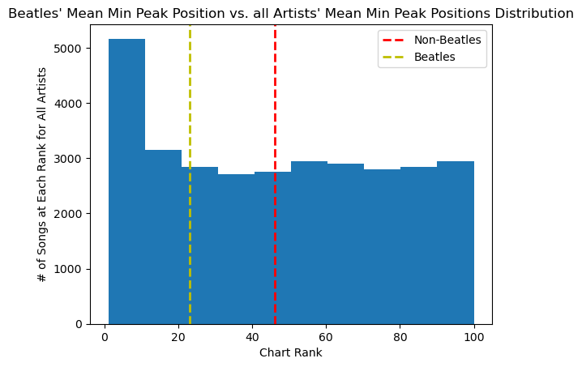

```python
min_performer_peak_pos_mean = int(min_performer_peak_pos_mean.iloc[0,0])
plt.axvline(
    min_performer_peak_pos_mean, color='r', linestyle='dashed',
    linewidth=2, label='Non-Beatles')
max1_beatles_min_peak_pos_mean = int(max1_beatles_min_peak_pos_mean.iloc[0,0])
plt.axvline(
    max1_beatles_min_peak_pos_mean, color='y', linestyle='dashed',
    linewidth=2, label='Beatles')
plt.title(
    "Beatles' Mean Min Peak Position vs. all Artists' \
Mean Min Peak Positions Distribution")
plt.legend()
plt.xlabel("Chart Rank")
plt.ylabel('# of Songs at Each Rank for All Artists')
plt.hist(data=min_performer_peak, x='peak_pos');
```

### Message 10 Part II: It is significant and obvious from a visual standpoint that claims could be made to hail the Beatles as the greatest rock band of all time. It can visually be seen that the Beatles average highest chart position for each of their songs is in the 75th percentile and all artists put together are in the 50th percentile, as the Beatles average minimum peak position for their songs was 23 and the industry-as-a-whole's average was 47. And The Beatles are included in the all artists' dataset, meaning they are even lifting the all-artists' mean up!

### Motivation 10 Part III: Including one-hit wonders, who has the most songs to hit the Billboard Hot 100?

### Method 10 Part III: preserve the true wks_on_chart & peak_pos mean values in the raw data (includes one-hit wonder data)

### Mechanics 10 Part III: let's add a column that counts the times a performer/title were on the charts and add a columns to the df with those counts

#### Python functions: pandas.groupby(); pandas.reset_index() - converts the index (especially when it is one or more text fields/columns) into regular columns and creates a new default integer - pops the row index back into a regular column in the dataframe and creates a normal numerical index (but by that time, you've most likely lost your original values so this method really doesn't work in the end if your looking to get back to original dataframe), and at that point you may have to add back the values you lost in the aggregation from some other source if you really need the popped-back-in dataframe (see below); pandas.merge(df_left, df_right, on='key' how=inner) - in this example, pd.merge() combines df_left and df_right where the values in the 'key' column match like an inner join in SQL only records with key column values that match will be returned

#### Python methods: pandas.count(); pandas.transform(), pandas.min() - takes the minimum value for the column specified in the groupby() function; copy() - instantiates a solid copy of a view into a variable vis-a-vis an assignment (usually coupled with a groupby() ))

#### Python attribute returned via method call: pandas.head() - shows sample table layout; all columns with first 5 rows

#### Python parameter: as_index=False - prevents the columns specified in the group by from becoming the index of the resulting recordset, leaving them just as regular columns and instead creates a numerical, sequential index column which allows more straightforward use of Python record attributes like iloc[index_num]

#### Python variables: grouped_df - df2 grouped by performer/title with counts of non-NaN values in each column; df2 - dataframe of raw source data uncollapsed, like df, but w/o any additional custom columns

```python
grouped_df = df2.groupby(['performer', 'title']).count()
# doing a free for all group by on all of the columns without using
# .agg will collapse the grouped by cols into rows instead of cols
# you'll have to do a reset_index if you do that like the line below
# grouped_df = grouped_df.reset_index()
grouped_df.head(3)
```

| performer | title | chart_week | current_week | last_week | peak_pos | wks_on_chart |
| --- | --- | --- | --- | --- | --- | --- |
| "Groove" Holmes | Misty | 11 | 11 | 10 | 11 | 11 |
|  | What Now My Love | 3 | 3 | 2 | 3 | 3 |
| "Little" Jimmy Dickens | May The Bird Of Paradise Fly Up Your Nose | 10 | 10 | 9 | 10 | 10 |

```python
%%html
<iframe width="560" height="315" src="https://www.youtube.com/embed/j3Y5UCzVElU?si=KY4Rj5W1MYjhstSv&autoplay=1;&amp;controls=1" title="YouTube video player" frameborder="0" allow="accelerometer; clipboard-write; encrypted-media; gyroscope; picture-in-picture; web-share" allowfullscreen></iframe>
<h3>Press the YouTube logo at the bottom of the video screen above to pop-out to a different tab and listen to in the background while you keep reading!</h3>
```

[video not shown]

Press the YouTube logo at the bottom of the video screen above to pop-out to a different tab and listen to in the background while you keep reading!

```python
grouped_df = grouped_df.reset_index()
# this is the main command you have to do to pop the rows back into columns,
# but by that time, you've lost
# you're original values so this method really doesn't work in the end
```

```python
grouped_df['hit_count'] = grouped_df.groupby(
    ['performer'], as_index=False)['title'].transform('count')
grouped_df['perf_woc_max'] = grouped_df.groupby(
    ['performer'], as_index=False)['wks_on_chart'].transform('max')
# grouped_df['perf_peak_min'] = grouped_df.groupby(['performer'],
# as_index=False)['song_peak_min'].transform('min')
# yes, it looks like this is going to work, just keep adding the columns
# back in from df2 (or df as well maybe - nah, probly not df since it is
# already cut down to only beatles by now)
grouped_df.head(3)
```

|  | performer | title | chart_week | current_week | last_week | peak_pos | wks_on_chart | hit_count | perf_woc_max |
| --- | --- | --- | --- | --- | --- | --- | --- | --- | --- |
| 0 | "Groove" Holmes | Misty | 11 | 11 | 10 | 11 | 11 | 2 | 11 |
| 1 | "Groove" Holmes | What Now My Love | 3 | 3 | 2 | 3 | 3 | 2 | 11 |
| 2 | "Little" Jimmy Dickens | May The Bird Of Paradise Fly Up Your Nose | 10 | 10 | 9 | 10 | 10 | 1 | 10 |

```python
grouped_df2 = df2.groupby(['performer','title']).min()
# doing a free for all group by on all of the columns without using
# .agg will collapse the grouped by cols into rows instead of cols
# you'll have to do a reset_index if you do that like the line below
grouped_df2 = grouped_df2.reset_index()
grouped_df2.head(3)
```

|  | performer | title | chart_week | current_week | last_week | peak_pos | wks_on_chart |
| --- | --- | --- | --- | --- | --- | --- | --- |
| 0 | "Groove" Holmes | Misty | 1966-06-25 | 44 | 44.0 | 44 | 1 |
| 1 | "Groove" Holmes | What Now My Love | 1966-10-01 | 96 | 98.0 | 96 | 1 |
| 2 | "Little" Jimmy Dickens | May The Bird Of Paradise Fly Up Your Nose | 1965-10-16 | 15 | 15.0 | 15 | 1 |

```python
#i need a df that has already been grouped down to perfomer/tite/e
# Merge df1 and df2 on both 'ID' and 'Name' columns
merged_df = pd.merge(grouped_df, grouped_df2, on=[
    'performer', 'title'], how='inner') #df doesn't work here for some reason--
# Print the merged DataFrame
merged_df.head()

# That's it - take performer, title, wks_on_chart_x, hit_count, perf_woc_max
# from grouped_df and peak_pos_y (for song) from grouped_df2
# only stat I seem to be missing is the perf_peak_min
```

|  | performer | title | chart_week_x | current_week_x | last_week_x | peak_pos_x | wks_on_chart_x | hit_count | perf_woc_max | chart_week_y | current_week_y | last_week_y | peak_pos_y | wks_on_chart_y |
| --- | --- | --- | --- | --- | --- | --- | --- | --- | --- | --- | --- | --- | --- | --- |
| 0 | "Groove" Holmes | Misty | 11 | 11 | 10 | 11 | 11 | 2 | 11 | 1966-06-25 | 44 | 44.0 | 44 | 1 |
| 1 | "Groove" Holmes | What Now My Love | 3 | 3 | 2 | 3 | 3 | 2 | 11 | 1966-10-01 | 96 | 98.0 | 96 | 1 |
| 2 | "Little" Jimmy Dickens | May The Bird Of Paradise Fly Up Your Nose | 10 | 10 | 9 | 10 | 10 | 1 | 10 | 1965-10-16 | 15 | 15.0 | 15 | 1 |
| 3 | "Pookie" Hudson | I Know I Know | 1 | 1 | 0 | 1 | 1 | 1 | 1 | 1963-05-25 | 96 | NaN | 96 | 1 |
| 4 | "Weird Al" Yankovic | Amish Paradise | 16 | 16 | 15 | 16 | 16 | 11 | 20 | 1996-03-30 | 53 | 53.0 | 53 | 1 |

```python
merged_df = merged_df.sort_values(by='hit_count', ascending=False)
merged_df.head()
```

|  | performer | title | chart_week_x | current_week_x | last_week_x | peak_pos_x | wks_on_chart_x | hit_count | perf_woc_max | chart_week_y | current_week_y | last_week_y | peak_pos_y | wks_on_chart_y |
| --- | --- | --- | --- | --- | --- | --- | --- | --- | --- | --- | --- | --- | --- | --- |
| 24890 | Taylor Swift | I Can See You (Taylor's Version) (From The Vault) | 7 | 7 | 7 | 7 | 7 | 206 | 53 | 2023-07-22 | 5 | 0.0 | 5 | 1 |
| 24997 | Taylor Swift | Treacherous (Taylor's Version) | 1 | 1 | 0 | 1 | 1 | 206 | 53 | 2021-11-27 | 54 | NaN | 54 | 1 |
| 24995 | Taylor Swift | Today Was A Fairytale | 18 | 18 | 17 | 18 | 18 | 206 | 53 | 2010-02-06 | 2 | 2.0 | 2 | 1 |
| 24994 | Taylor Swift | Timeless (Taylor's Version) (From The Vault) | 1 | 1 | 1 | 1 | 1 | 206 | 53 | 2023-07-22 | 48 | 0.0 | 48 | 1 |
| 24993 | Taylor Swift | Tim McGraw | 20 | 20 | 19 | 20 | 20 | 206 | 53 | 2006-09-23 | 40 | 40.0 | 40 | 1 |

```python
merged_df_swift = merged_df[
    merged_df['performer']=='Taylor Swift'].sort_values(by='title')
with pd.option_context('display.max_rows', None):
    print(merged_df_swift)
```

```
          performer                                              title  \
24815  Taylor Swift                               'Tis The Damn Season
24816  Taylor Swift                                   ...Ready For It?
24817  Taylor Swift                                                 22
24818  Taylor Swift                              22 (Taylor's Version)
24819  Taylor Swift                                          Afterglow
24820  Taylor Swift                  All Of The Girls You Loved Before
24821  Taylor Swift                                       All Too Well
24822  Taylor Swift                    All Too Well (Taylor's Version)
24823  Taylor Swift      All You Had To Do Was Stay (Taylor's Version)
24824  Taylor Swift                                          Anti-Hero
24825  Taylor Swift                                             August
24826  Taylor Swift           Babe (Taylor's Version) (From The Vault)
24827  Taylor Swift                                   Back To December
24828  Taylor Swift                Back To December (Taylor's Version)
```

[output cut: 816 more lines]

### Message 10 Part III: My eyes absolutely popped out when I saw how many hit singles this performer had, which topped the list. I thought I had miscalculated or mis-coded, but nope -- I double-checked, as can be seen above, and the artist with the most hit singles in the history of the Billboard Hot 100 is Taylor Swift with a mind-boggling 206 hits...TWO-HUNDRED-AND-SIX!!! Good lord! Kudos to you Taylor, I do like that Anti-Hero song of yours and Shake It Off is a classic that captured a moment in time...

```python
%%html
<iframe width="560" height="315" src="https://www.youtube.com/embed/b1kbLwvqugk?si=KY4Rj5W1MYjhstSv&autoplay=1;&amp;controls=1" title="YouTube video player" frameborder="0" allow="accelerometer; clipboard-write; encrypted-media; gyroscope; picture-in-picture; web-share" allowfullscreen></iframe>
<h3>Press the YouTube logo at the bottom of the video screen above to pop-out to a different tab and listen to in the background while you keep reading!</h3>
```

[video not shown]

Press the YouTube logo at the bottom of the video screen above to pop-out to a different tab and listen to in the background while you keep reading!

### Motivation 10 Pt. III.5: What if we take out all of the one-hit wonders and see what the average minimum peak position is and average maximum weeks on the chart for each performer? How do the numbers trend? Better or worse?

### Method 10 Pt. III.5: Now use the new no one-hit wonders means and peak positions to redo the comparison and chart above.

### Mechanics 10 PT. III.5: Group the bins

#### Python functions: hist() creates histogram graphs for each column in the dataframe specified in prefix

#### Python method: mean() - returns the average of the specified data column; copy() - instantiates a solid copy of a view into a variable vis-a-vis an assignment (usually coupled with a groupby() ))

#### Python parameter: as_index=False - prevents the columns specified in the group by from becoming the index of the resulting recordset, leaving them just as regular columns and instead creates a numerical, sequential index column which allows more straightforward use of Python record attributes like iloc[index_num]

```python
## grouped_df[grouped_df[('hit_count')] > 1]
grouped_df_noOneHits = merged_df[merged_df[('hit_count')] > 1].copy()
# yes this is what i want but do it on df2 instead to not lose the
# peak_pos & woc means when determining the hit_count col?
```

### Now come up with the min peaks for each performer and call perf_peak_min

```python
# grouped_df_noOneHits['woc_max0'] = df2.groupby(['performer'], as_index=False)['wks_on_chart'].transform('max')
grouped_df_noOneHits['perf_peak_min'] = grouped_df_noOneHits.groupby(
    ['performer'], as_index=False)['peak_pos_y'].transform('min')
grouped_df_noOneHits.head()
# this gets new mean of non-one hit wonder song-artist combos
```

|  | performer | title | chart_week_x | current_week_x | last_week_x | peak_pos_x | wks_on_chart_x | hit_count | perf_woc_max | chart_week_y | current_week_y | last_week_y | peak_pos_y | wks_on_chart_y | perf_peak_min |
| --- | --- | --- | --- | --- | --- | --- | --- | --- | --- | --- | --- | --- | --- | --- | --- |
| 24890 | Taylor Swift | I Can See You (Taylor's Version) (From The Vault) | 7 | 7 | 7 | 7 | 7 | 206 | 53 | 2023-07-22 | 5 | 0.0 | 5 | 1 | 1 |
| 24997 | Taylor Swift | Treacherous (Taylor's Version) | 1 | 1 | 0 | 1 | 1 | 206 | 53 | 2021-11-27 | 54 | NaN | 54 | 1 | 1 |
| 24995 | Taylor Swift | Today Was A Fairytale | 18 | 18 | 17 | 18 | 18 | 206 | 53 | 2010-02-06 | 2 | 2.0 | 2 | 1 | 1 |
| 24994 | Taylor Swift | Timeless (Taylor's Version) (From The Vault) | 1 | 1 | 1 | 1 | 1 | 206 | 53 | 2023-07-22 | 48 | 0.0 | 48 | 1 | 1 |
| 24993 | Taylor Swift | Tim McGraw | 20 | 20 | 19 | 20 | 20 | 206 | 53 | 2006-09-23 | 40 | 40.0 | 40 | 1 | 1 |

```python
# grouped_df_noOneHits['all_peak_mean'] = grouped_df_noOneHits['perf_peak_min'].mean() # <-- group by to get the mean of the perf_peak_min and mean of perf_woc_max
# remember code above to do a group by of one column by a certain agg f(x)
# taking the above line out and just taking mean of df before taking max
# of wks_on_hcart & peak_pos gives you weighted average that relates the
# more records the more weight the peak_pos has for that record
min_peak_no1 = grouped_df_noOneHits['perf_peak_min'].mean()
print(str(int(min_peak_no1)) + " is the average performer's best rank /\n"+\
      "   lowest peak position number value after 1-hit wonders removed")
max_woc_no1 = grouped_df_noOneHits['perf_woc_max'].mean()
print(str(int(max_woc_no1)) + " is the average performer's longest # of\n"+\
      "   weeks on the charts for one song after 1-hit wonders removed")
```

```
11 is the average performer's best rank /
   lowest peak position number value after 1-hit wonders removed
22 is the average performer's longest # of
   weeks on the charts for one song after 1-hit wonders removed
```

### Message 10 Pt. III.5: 11 is a typical performer's best rank / lowest peak position number value for any song of theirs after 1-hit wonders are removed from the dataset. 22 is a typical performer's longest # of weeks on the charts for any song of theirs. Beatles are included in the dataset. So the numbers get better for the average minimum peak position from 47 to 11 for all artists and they also get better for average max weeks on the chart per performer going from 11 to 22 weeks! It is clear one-hit wonders drag the Billboard Hot 100 down in both of these categories. They have shorter than average weeks on the chart for their best songs and greater (farther away from #1) than average minimum peak positions for non-one hit wonder performers.

### Mechanics 10 Part IV: Create histograms to graph the values of each grouped-by-performer dataframe columns.

#### Python function: hist() - creates histograms for each numerical column for the dataframe specified in the statement prefix; groupby(); int() - creates integers for ease of graphing; pyplot.axvline - creates a vetical line on the horizontal axis; title - creates a title for the graph

#### Python method: agg()

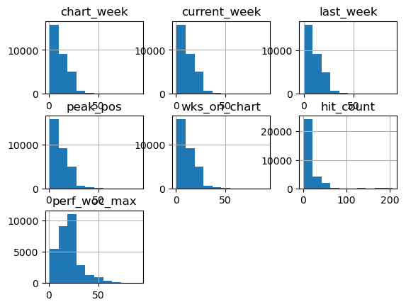

```python
grouped_df.hist();
```

[figure not shown]

```python
max_wks_peak_beat_no1s = df.groupby(
    ['performer', 'title'], as_index=False).agg(
    {'wks_on_chart': 'max', 'peak_pos': 'min'})
max_wks_peak_beat_mean_no1s = max_wks_peak_beat_no1s.groupby(
    by='performer').agg(x=('peak_pos','mean'))
max_wks_peak_beat_mean_no1s
min_performer_peak_no1s = df2.groupby(
    ['performer', 'title'], as_index=False).agg({'peak_pos': 'min'})
min_performer_peak_pos_mean_no1s = min_performer_peak_no1s.agg(
    x=('peak_pos','mean'))
min_performer_peak_no1s.agg(x=('peak_pos','mean'))
min_performer_peak_pos_mean_no1s = int(
    min_performer_peak_pos_mean_no1s.iloc[0,0])
plt.axvline(
    min_peak_no1, color='r', linestyle='dashed', linewidth=2, \
    label="Mean Minimum Peak Position (Highest Chart Rank)")
max_wks_peak_beat_mean_no1s = int(
    max_wks_peak_beat_mean_no1s.iloc[0,0])
plt.axvline(
    max_wks_peak_beat_mean_no1s, color='y', linestyle='dashed',\
    linewidth=2, label="Mean Maximum Weeks on the Chart")
plt.title("No 1-hit wonders! All Artists' Avg Min Peak Position vs. \
# of Songs at Each Chart Rank")
plt.ylabel("# of Performers at their Highest Chart Rank")
plt.xlabel("Both Chart Rank / # of Weeks on the U.S Billboard Hot 100 Chart")
plt.legend()
plt.hist(data=grouped_df_noOneHits, x='perf_peak_min');
```

### Message 10 Pt. IV: To answer my question about the multiple-column histys above; yes one data point, "perf_woc_max" was interesting as it appears the median is right around what was predicted at about 22 -- so reinforcing the point there with **Data Visualization**, which is exactly the point of doing both visual and math proofs. The Beatles average highest position rank was 23. They would not be re-signed with this performer avg min peak pos after one-hit wonders were removed since industry avg performer min peak was 11 and 11 <= 23. Which means that most 1-hit wonders weren't chart toppers since the mean went up for the population afterwards. Getting rid of the one-hit wonders makes overall career performer minimum peak position higher ranked (less value / closer to 1.) However, I believe if The Beatles were removed from this data the 11 average minimum peak would fall significantly, maybe even to below 23. Perhaps another question/motivation for next time...

### Motivation 11: If we re-include one-hit wonders back in the following data, how many bands had songs on the chart longer than the Beatles song on the charts the longest?

### Method 11: Let's deal only with data where only performers who had at least one song on the charts longer than "Twist And Shout" at 26 wks.

### Mechanics 11: Create new df only with performers who had songs on charts longer than "Twist And Shout". Now assign the mean for wks_on_chart and peak_pos to two new columns in the df, so can plot them. Hmmm, maybe I'll do a max & min respectively instead. Maybe don't worry about doing plot of those two vars and just go straight to MRM (Mulitvariate Regression Models). Count the number of bands with songs on the charts longer than the Beatles song on the charts the longest ("Twist and Shout")

#### New Python modules: numpy - for numerical computation. It provides support for large, multi-dimensional arrays and matrices, along with a vast collection of high-level mathematical functions to operate on these arrays efficiently.

#### Python functions: transpose() - For a 2-dimensional array (a matrix), the transpose() operation effectively swaps the rows and columns; rename() - renames columns from one label to another; dropna() - drops all of NaN records; where() - returns a tuple of index arrays, one for each dimension of the input array, indicating the indices where the condition is True.

```python
import numpy as np
results = np.where((max3['wks_on_chart'] > bmaxweeks), (
    max3['performer'], max3['title'], max3['wks_on_chart']), np.nan)
df3 = pd.DataFrame(results).transpose()
df3=df3.rename(columns={0:"Performer",1:"Title", 2:"Wks_On_Chart"})
df3 = df3.dropna()
print (df3)
```

```
            Performer                      Title Wks_On_Chart
0       Glass Animals                 Heat Waves           91
1          The Weeknd            Blinding Lights           90
2     Imagine Dragons                Radioactive           87
3          AWOLNATION                       Sail           79
4            Dua Lipa                 Levitating           77
...               ...                        ...          ...
1255           Calboy                    Envy Me           27
1256          50 Cent             Just A Lil Bit           27
1257              US3  Cantaloop (Flip Fantasia)           27
1258      Gary Wright              Love Is Alive           27
1259             P!nk                 Most Girls           27

[1260 rows x 3 columns]
```

```python
%%html
<iframe width="560" height="315" src="https://www.youtube.com/embed/ktvTqknDobU?si=KY4Rj5W1MYjhstSv&autoplay=1;&amp;controls=1" title="YouTube video player" frameborder="0" allow="accelerometer; clipboard-write; encrypted-media; gyroscope; picture-in-picture; web-share" allowfullscreen></iframe>
<h3>Press the YouTube logo at the bottom of the video screen above to pop-out to a different tab and listen to in the background while you keep reading!</h3>
```

[video not shown]

Press the YouTube logo at the bottom of the video screen above to pop-out to a different tab and listen to in the background while you keep reading!

```python
print ("The Beatles longest run of weeks on the chart in America was for ")
print (str(max1.iloc[0].wks_on_chart) + " weeks.")
```

```
The Beatles longest run of weeks on the chart in America was for
26 weeks.
```

```python
print ("There were " + (str(len(df3.index))) + \
" other acts that had songs with longer runs than that.")
```

[output not shown]

### High-Level Message: The many conclusions drawn in the Messages in this presentation fully support the Beatles being hailed as the Greatest Rock Band of all Time -- the Best Rock Band to have ever existed. However, in all fairness, it is clear that Taylor Swift is without a doubt currently the Best Active Pop Act. Her record sales, sold-out concert frenzy, Taylormania & loyal legions of "Swifties", the "Taylor Swift effect" / "Swiftonomics" verbiage that has been coined by economists documenting the monetary windfall she brings to local economies that are home to the venues she plays -- not to mention that, like the Beatles, college and high school courses have been devoted to analyzing her music and lyrics; all more than support her crowning as the reigning Queen of Pop and is now currently the Best Active Pop Act on the Planet. She has more than earned her place in the conversation, along with the Beatles, about being the Best Pop Act Ever. Although, if one wants to see the Best Rock Act on the Planet, one would be better served going to a Paul McCartney or Ringo Starr concert; seeing as how they're the current Grammy Award holders for Best Rock Performance! More questions answered with Data Science next time...!

```python
%%html
<iframe width="560" height="315" src="https://www.youtube.com/embed/tgIqecROs5M?si=KY4Rj5W1MYjhstSv&autoplay=1;&amp;controls=1" title="YouTube video player" frameborder="0" allow="accelerometer; clipboard-write; encrypted-media; gyroscope; picture-in-picture; web-share" allowfullscreen></iframe>
<h3>Press the YouTube logo at the bottom of the video screen above to pop-out to a different tab and listen to in the background while you keep reading!</h3>
```

[video not shown]

Press the YouTube logo at the bottom of the video screen above to pop-out to a different tab and listen to in the background while you keep reading!